# kara_text_lab

Kara

10/19/2021

### Midwestern Sentiment Analysis

Using Lexis Nexis, 10 articles from Midwestern newspapers were selected. These articles were saved as text files. The data was loaded into R and then combined into one data frame to perform sentiment analysis and develop word clouds.

Below is a graph depicting the top 20 most prevalent words after removing stop words and the words “climate”, “change”, “global”, and “warming”. These additional words were removed because they are the topic of interest and we are investigating the sentiment around them, not from them.

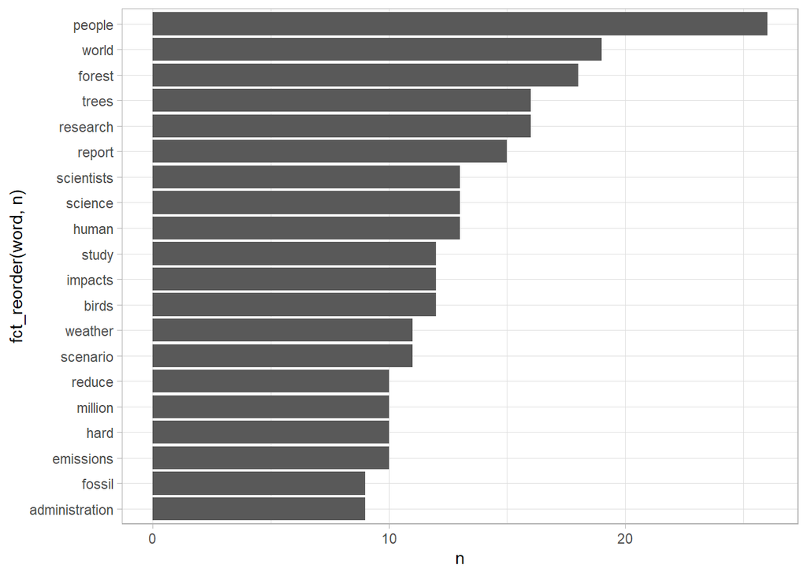

With the data now cleaned and the words tokenized, sentiment analysis was then performed using AFINN, NRC, and Bing lexicons provided through the TidyText package.

#### Bing Lexicon

Below is a graph showing the top 10 most prevalent words in Bing’s classification of “positive” and negative “sentiment”. From these top 10 words it appears that climate change is more associated with negative sentiment as the most prominent words are ones like “hard”, “threat”, and “risk”.

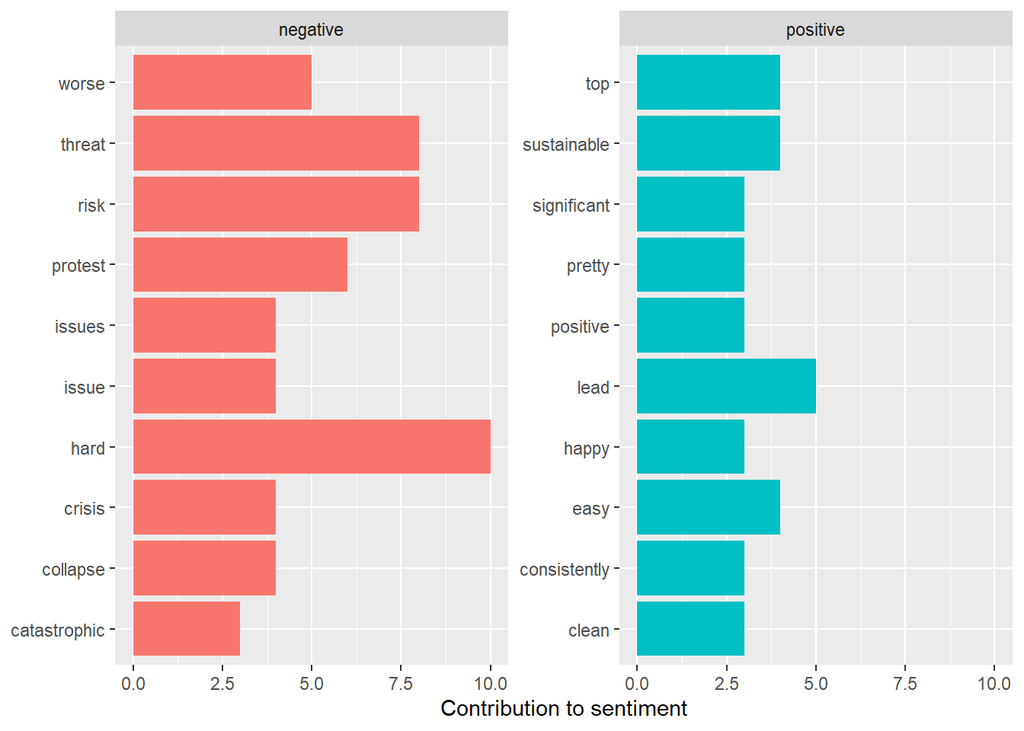

This is also emphasized when looking at the frequency of terms where the the number of negative terms is double that of the positive.

```
##
## negative positive
##      158       79
```

#### NRC Lexicon

Interestingly the NRC lexicon has a much different distribution of positive and negative sentiment with the positive exceeding the negative. However, negative emotions like anger, fear, and sadness are quite prevalent which is aligned with the results from the Bing lexicon.

```
##
##        anger anticipation      disgust         fear          joy     negative
##           68           84           29           87           53          141
##     positive      sadness     surprise        trust
##          187           70           41          108
```

#### AFINN

The AFINN lexicon had results consistent with the Bing lexicon with the histogram skewed towards negative values indicating a more negative sentiment towards climate change.

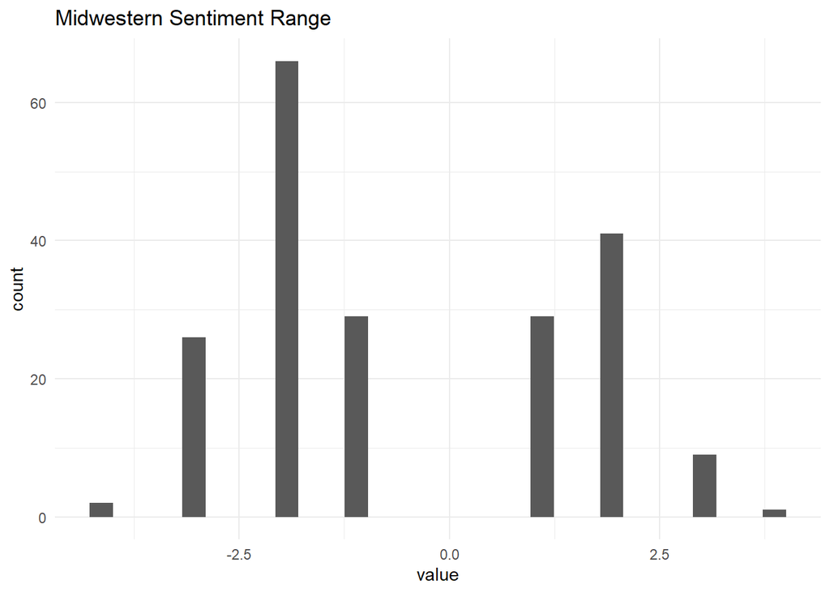

#### Word Cloud

Below is a word cloud representing the top 50 most prevalent words. From the word cloud we can see that much of the news around climate change is centered around three key aspects: people (“people”, “human”), nature (“forest”, “trees”, “birds”), and science (“research”, “scientists”). I especially found it interesting how large “people” and “human” are compared to the other words. I feel like this reflects the tendency to place human priorities above the environment which is a major contributing factor to climate change.

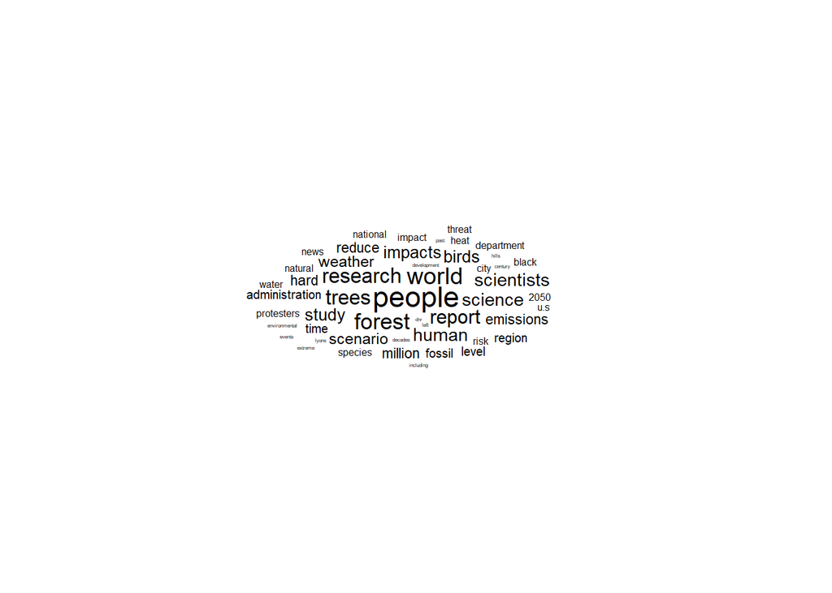

#### Regional TF-IDF

To better understand the sentiment distribution on a national level, 3 major regions were considered: Southern, Midwestern, and Western. Articles from major newspapers in each of these regions were compiled into one large text file. The 3 regions’ text were then compiled into a data frame to perform a term frequency individual document frequency (TF-IDF) analysis. In this analysis the corpus is considered to be the newspaper articles selected nationally, while the individual documents are considered to be the articles collated from a particular region.

Using TF-IDF scores below is a plot showing the top 10 most impactful words in each region. Interestingly, there is no overlap between the three regions. This indicates that we may need to have very targeted campaigns for each region.

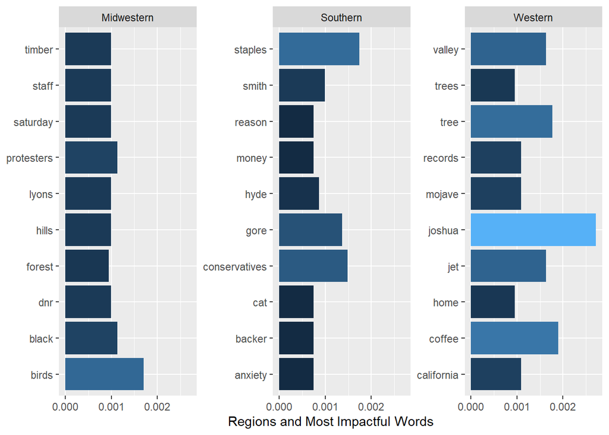

Looking more closely at the top 10 most impactful words per region we can get an initial idea of the type of campaign we will want to run to target people in these regions.

For the Midwestern region many of the words (“birds”, “forest”, “hill”, ect.) have to do with things in the natural world. With this information our campaign should emphasize the impacts of climate change on the environment around us.

On the other hand, the Southern region is much more occupied with political themes like “conservatives”, “backer”, and “money”. The Southern campaign should focus on highlighting political iniatives.

The Western region is focused on the immediate natural environment shown through the words “Joshua” (likely from Joshua Tree) and “Mojave”. Therefore, the Western campaign should focus specifically on the natural world in California and emphasize climate change impacts on beloved National Parks.